# MTH6139 Time Series

Coursework 1

Sumaya Osman

Spring term 2025

# Section 1: UK Lung Deaths

## 1.1 About Dataset

This data set is a total deaths from bronchitis, emphysema and asthma in the Uk from 1974-1979.

The aim of this project is to use Meta’s Prophet forecasting system to use historical data to predict future trends. I will also be identifying trends or seasonal patterns in Deaths from lung diseases.

## 1.2 Linear Model

We will firstly use the function `lm` to run a regression.

```r
#both sexes
ldeaths.df=data.frame(
    ds=zoo::as.yearmon(time(ldeaths)),
    y=ldeaths
)
ds=zoo::as.yearmon(time(ldeaths))
y=ldeaths
model=lm(y~ds,data=ldeaths.df)
summary(model)
```

```
##
## Call:
## lm(formula = y ~ ds, data = ldeaths.df)
##
## Residuals:
##    Min     1Q Median     3Q    Max
## -790.2 -470.7 -165.7  401.4 1756.0
##
## Coefficients:
##              Estimate Std. Error t value Pr(>|t|)
## (Intercept) 179088.42   79869.98   2.242   0.0281 *
## ds             -89.55      40.40  -2.217   0.0299 *
## ---
## Signif. codes:  0 '***' 0.001 '**' 0.01 '*' 0.05 '.' 0.1 ' ' 1
##
## Residual standard error: 593.7 on 70 degrees of freedom
## Multiple R-squared:  0.06558,    Adjusted R-squared:  0.05223
## F-statistic: 4.913 on 1 and 70 DF,  p-value: 0.02991
```

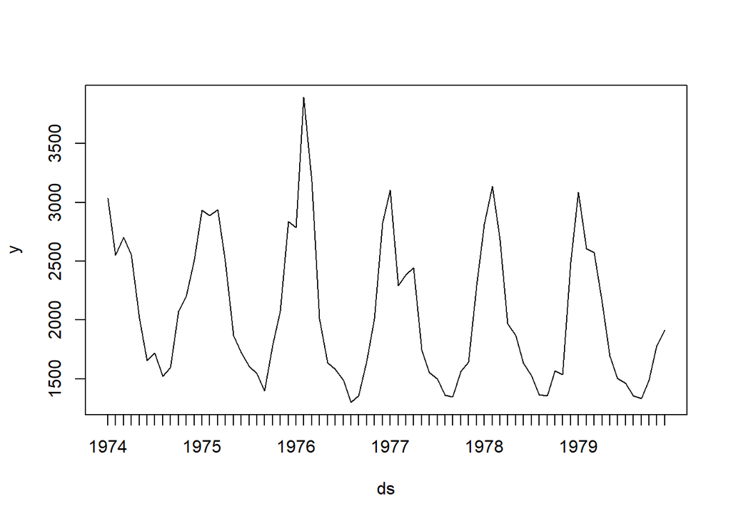

```r
plot(ds,y,type="l")
```

## Comparison between Men and Women

```r
fdeaths.df=data.frame(
     ds=zoo::as.yearmon(time(fdeaths)),
     y=fdeaths
 )
mdeaths.df=data.frame(
     ds=zoo::as.yearmon(time(mdeaths)),
     y=mdeaths
 )

#Men
ds=zoo::as.yearmon(time(mdeaths))
y=mdeaths
model=lm(y~ds,data=mdeaths.df)
summary(model)
```

```
##
## Call:
## lm(formula = y ~ ds, data = mdeaths.df)
##
## Residuals:
##    Min     1Q Median     3Q    Max
## -552.2 -340.4 -136.6  261.9 1192.7
##
## Coefficients:
##              Estimate Std. Error t value Pr(>|t|)
## (Intercept) 140072.22   56299.86   2.488   0.0152 *
## ds             -70.10      28.48  -2.461   0.0163 *
## ---
## Signif. codes:  0 '***' 0.001 '**' 0.01 '*' 0.05 '.' 0.1 ' ' 1
##
## Residual standard error: 418.5 on 70 degrees of freedom
## Multiple R-squared:  0.07966,    Adjusted R-squared:  0.06651
## F-statistic: 6.058 on 1 and 70 DF,  p-value: 0.01631
```

```r
#Women
ds1=zoo::as.yearmon(time(fdeaths))
y1=fdeaths
model1=lm(y1~ds1,data=fdeaths.df)
summary(model1)
```

```
##
## Call:
## lm(formula = y1 ~ ds1, data = fdeaths.df)
##
## Residuals:
##     Min      1Q  Median      3Q     Max
## -242.81 -141.38  -46.92  118.49  563.30
##
## Coefficients:
##             Estimate Std. Error t value Pr(>|t|)
## (Intercept) 39016.20   23911.72   1.632    0.107
## ds1           -19.45      12.10  -1.608    0.112
##
## Residual standard error: 177.7 on 70 degrees of freedom
## Multiple R-squared:  0.03563,    Adjusted R-squared:  0.02186
## F-statistic: 2.586 on 1 and 70 DF,  p-value: 0.1123
```

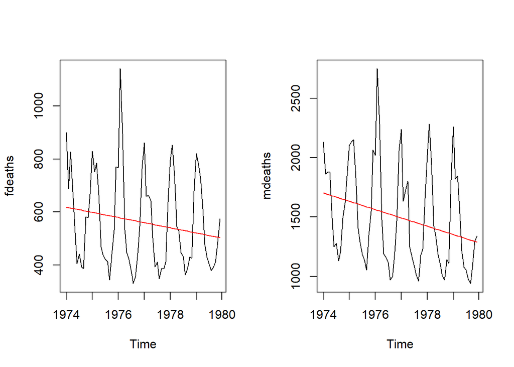

```r
#Plots
par(mfrow = c(1, 2))
plot(fdeaths);lines(ds1,fitted(model1),type="l",col="red")
plot(mdeaths);lines(ds,fitted(model),type="l",col="red")
```

The 2 plots highlight a clear difference between the number of deaths due to lung disease in men and women. Women had a significantly lower number of deaths in 1974 (around 900) and decreased to around 600 by 1980. However Men in the UK started with a much higher figure (around 2100 deaths) but eventually decreased to around 1400 deaths, which is still considerably higher than Women. This disparity could result from lifestyle difference, genetics or other contributing factors.

# Section 2: Prophet forecasting

We will now use Meta’s forecasting system , prophet, using the dataset of total Deaths from both genders `ldeaths` for a period of 2 years, 4 years, 8 years and 30 years.

## 2.1 2 year Forecast

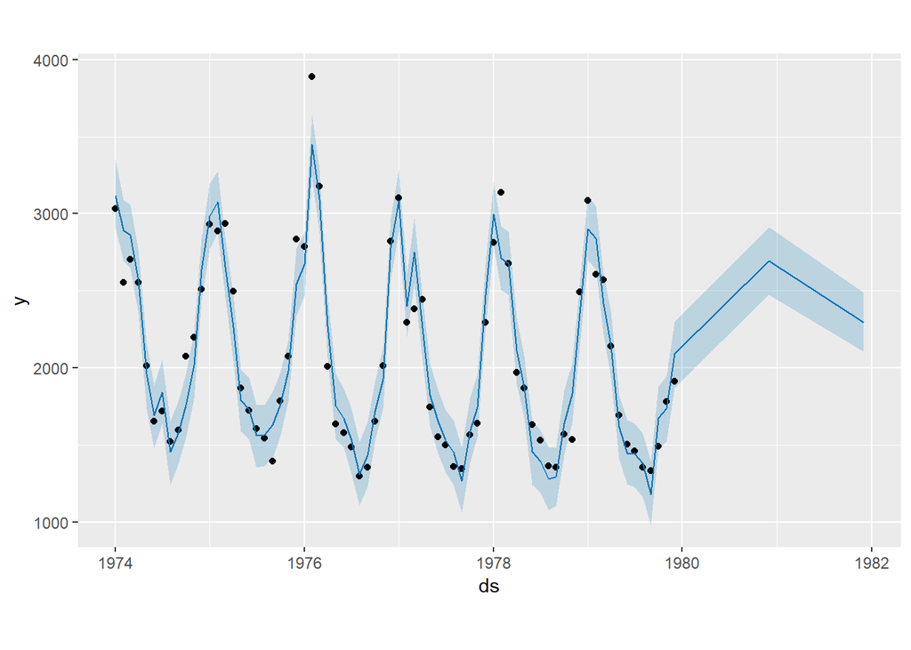

```r
ldeaths.df=data.frame(
    ds=zoo::as.yearmon(time(ldeaths)),
    y=ldeaths
)
m=prophet::prophet(ldeaths.df,yearly.seasonality=TRUE,weekly.seasonality=TRUE,daily.seasonality=TRUE)
f=prophet::make_future_dataframe(m,periods=2,freq="year")
p=predict(m,f)
plot(m,p)
```

We can use the function `prophet_plot_components` to view the forecast broken down intro trend, weekly seasonality and yearly seasonality.

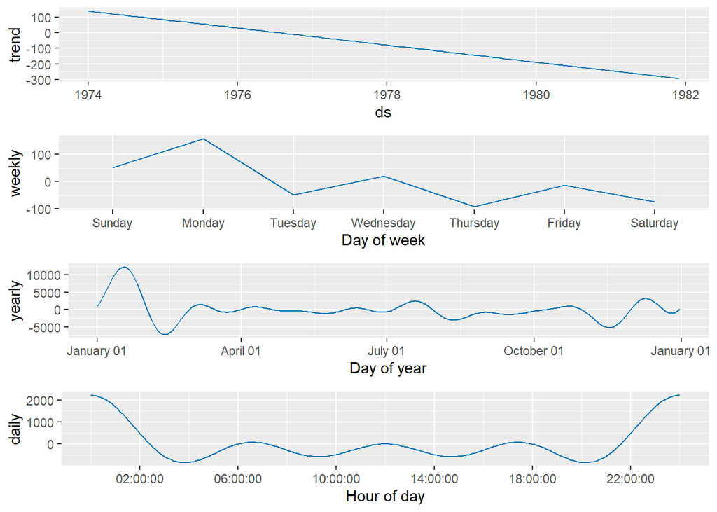

```r
prophet::prophet_plot_components(m, p)
```

```r
prophet::dyplot.prophet(m, p)
```

[interactive chart not shown]

This interactive plot allows for further specific exploration of the data at certain points in time.

## 2.2 4 year Forecast

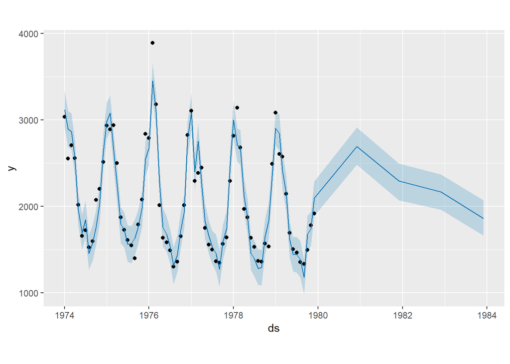

```r
f1=prophet::make_future_dataframe(m,periods=4,freq="year")
p1=predict(m,f1)
plot(m,p1)
```

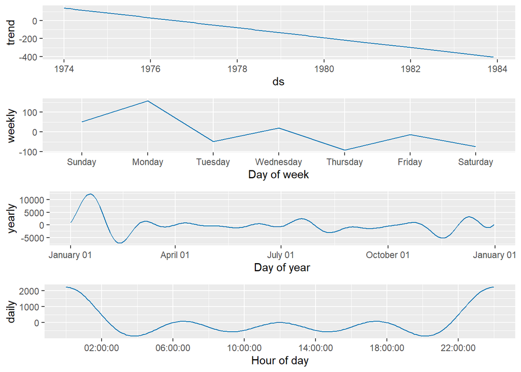

```r
prophet::prophet_plot_components(m, p1)
```

## 2.3 8 year Forecast

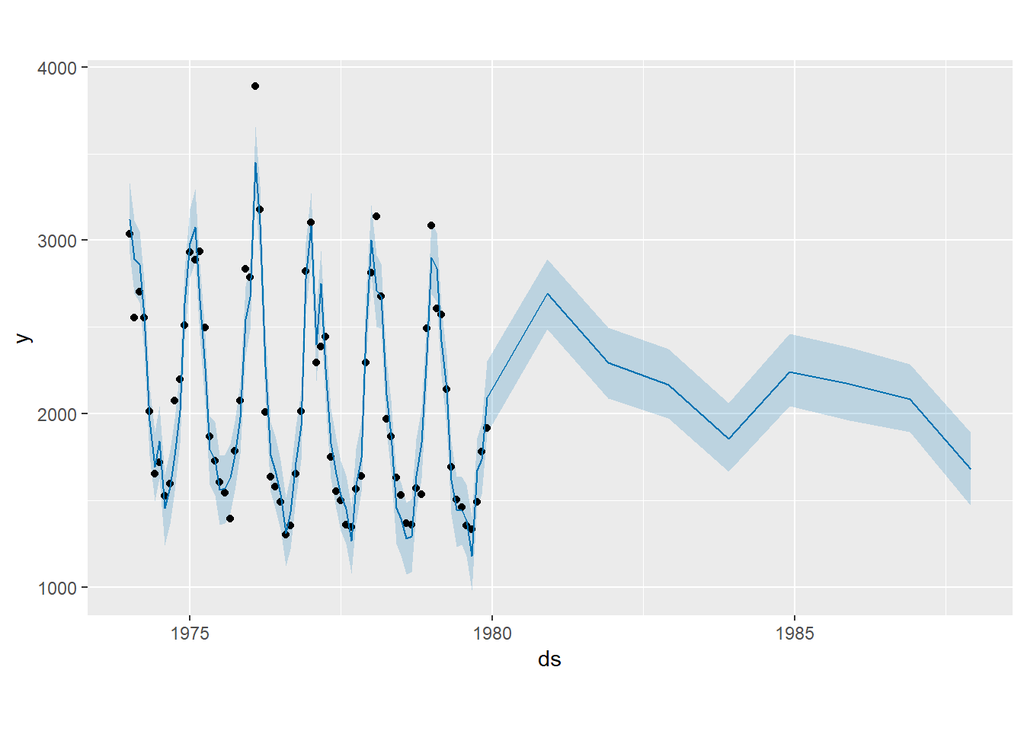

```r
f2=prophet::make_future_dataframe(m,periods=8,freq="year")
p2=predict(m,f2)
plot(m,p2)
```

## 2.4 30 year Forecast

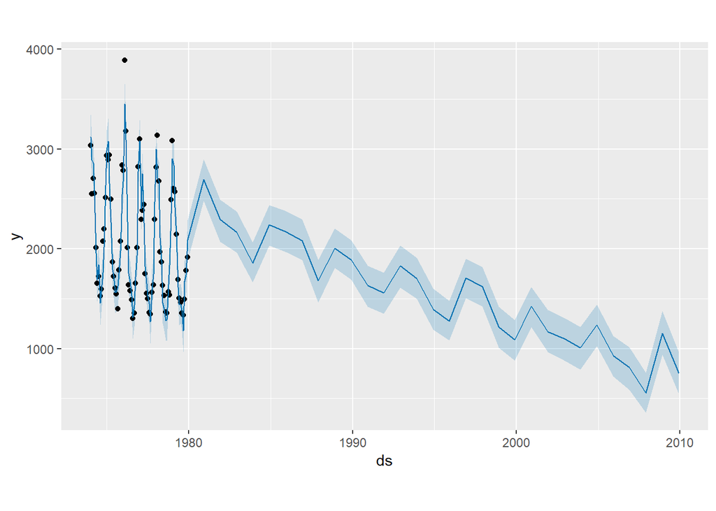

```r
f3=prophet::make_future_dataframe(m,periods=30,freq="year")
p3=predict(m,f3)
plot(m,p3)
```

It’s clear from these forecasts that there is general decrease in total deaths in the UK. As we increase the Forecast period, we observe a more substantial drop in deaths, from which we can only assume that it will continue on this trend for the foreseeable future; indicating meaningful changes in societal norms (such as smoking) and quality of healthcare.